# VSS Supplemental Material

For futher information, visit [our article](https://link.springer.com/article/10.3758/s13414-020-02028-9) on Attention, Perception, & Psychophysics.

Click [here](https://honamik-s.github.io/vss2020/poster) for the html version of the poster.

# Modeling

The number of hits per participants in each condition is represented as:

$$\alpha_{i,k}\sim {\sf Binomial}(n_{i,k}, \theta_{i,k})$$

$n$ is a number of trials and $\theta$ describes a hit rate. The subscripts $i$ and $k$ refer, respectively, to each participant and context condition (two levels – repeated or new).

This model is derived from conventional SAT functions. Hence $\lambda$ is an asymptotic parameter, whereas $\beta$ and $\delta$ are the pre-asymptotic parameters that describe a portion of the function before $\theta$ reaches an asymptote; 0.5 was added to the conventional SAT function in order for $\delta$ to be a parameter reflecting the time point when $\theta$ leaves the chance level, 50%.

The conventional interpretation of each parameter is as follows:

- $\beta$: the growth rate
- $\delta$: the starting point of the growth
- $\lambda$: the accuracy threshold

We used the Stan and RStan package (Stan Development Team, 2019), the R interface to Stan, to construct and compute the model. The parameters in models were estimated by generating Markov-Chain Monte Carlo (MCMC) samples from posterior distributions. In order for the estimates to be stable, we used 12,000 steps of four MCMC chains, among which 2,000 steps were discarded as a warm-up. We concluded that chains converged successfully when $\hat{R}$ values were under 1.04.

The main component of the model code written in Stan is shown below:

```
model{
  // Priors
  target += normal_lpdf(mu_beta[cond] | 0, 10);
  target += normal_lpdf(mu_delta | 0, 10);
  target += normal_lpdf(mu_lambda | 0, 0.5);

  target += cauchy_lpdf(sigma_beta | 0, 2.5) - cauchy_lccdf(0 | 0, 2.5);
  target += cauchy_lpdf(sigma_delta | 0, 2.5) - cauchy_lccdf(0 | 0, 2.5);
  target += cauchy_lpdf(sigma_lambda | 0, 2.5) - cauchy_lccdf(0 | 0, 2.5);

  for (i in 1:subjN) {
    target += normal_lpdf(lambda_raw[i] | mu_lambda, sigma_lambda);
    target += lognormal_lpdf(delta[i] | mu_delta, sigma_delta);
    for (k in 1:cond) {
      target += lognormal_lpdf(beta[i][k] | mu_beta[k], sigma_beta);

    }
  }

  for (i in 1:subjN) {
    for (j in 1:soaN) {
      for (k in 1:cond) {
        real theta;
        if (soa[j] > delta[i]){
          theta = C + lambda[i] * (1-exp(-beta[i][k] * (soa[j] - delta[i])));
        }
        else {
          theta = C;
        }
        target += binomial_lpmf(RespN[i,j,k] | TrialN[i,j,k], theta);
      }
    }
  }
}
```

# Parameter Estimation

In order to examine changes in pre-asymptotic parameters $\beta$ and $\delta$ as a function of context conditions, we constructed four models:

1. a model in which both $\beta$ and $\delta$ are variable across the two context conditions (full model)
2. a model in which only $\beta$ varies across the conditions (2$\beta$ model)
3. a model in which only $\delta$ varies across the conditions (2$\delta$ model)
4. a model in which neither of these two parameters varies across the conditions (null model).

Comparisons between the models with negative log marginal likelihoods (i.e. free energy) and Bayes factors showed that the 2$\beta$ model fits better with the current data. For further details about the model comparisons, see the Modeling section in our article. The parameter estimates from the 2$\beta$ model are shown below.

## $\beta$: Growth rate

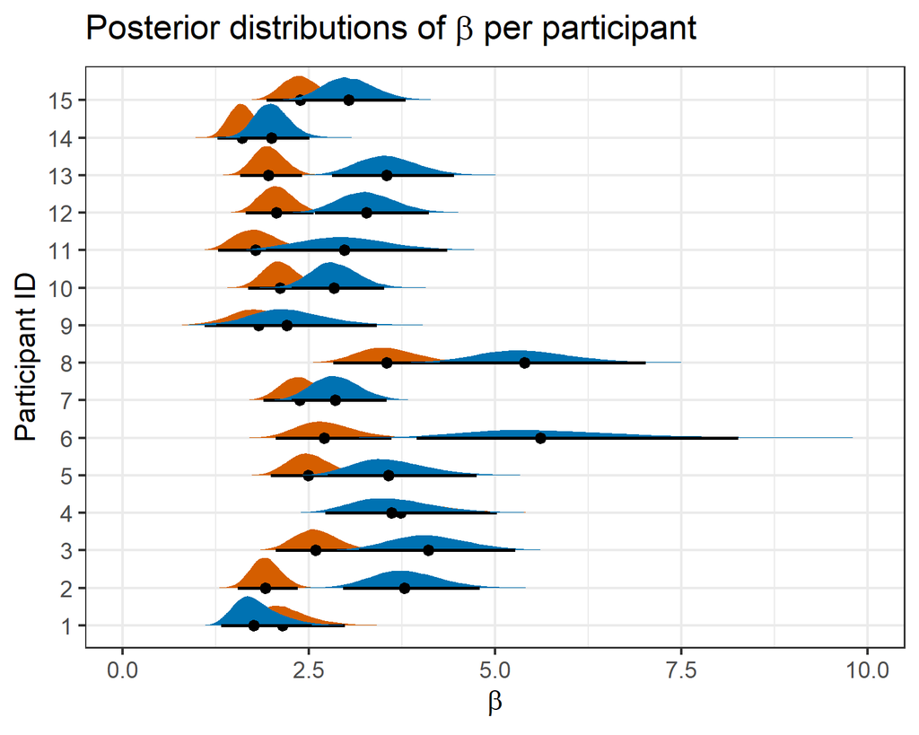

The blue density plot represents the repeated condition, and the red density plots represents the new condition.

## $\delta$: Starting point

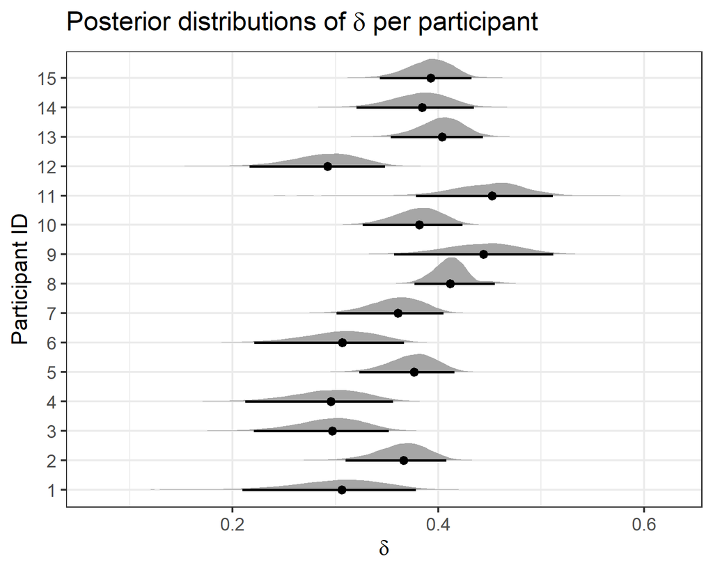

## $\lambda$: Asymptote

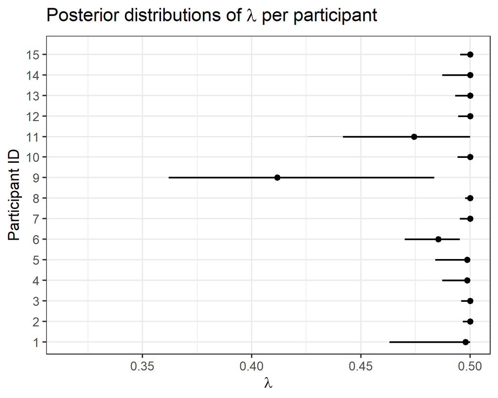

Honami Kobayashi

Updated: 2020-06-18